# NH-NC-GA Environment Comparison

## Site comparison

NERRS buoys have proven to be reliable and methodologically comparable between sites. Further, there are several buoy options within each NERRS which can be useful when determining collection sites of Urosalpinx. The figure below compares the water temperatures between NERRS buoy sites in Great Bay, NH (GRBGBWQ) and Sapelo, GA (SAPDCWQ) for the year 2021. Note that Great Bay temperature records do not begin until April due to ice conditions in the estuary. The record also can terminate early in November or December in NH because of ice.

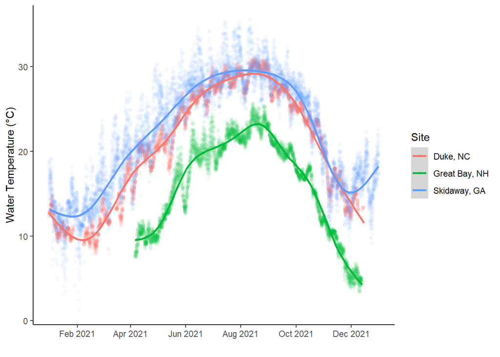

## Potential issues with data sourcing

### Great Bay

The Great Bay buoy site here is from the middle of the basin, 1.97 km from the original Urosalpinx Great Bay collection site. The Jackson Estuarine Lab (UNH) has historically collected water temperature data from their flowing seawater systems, the intake of which is much closer to our collection site of Urosalpinx (less than a kilometer). I have obtained data from 2018 from a contact at the lab, but have learned that they stopped doing this in 2019. Below is the data from 2018 from the Jackson lab overlaid on the Great Bay buoy data. The warming at the end of the Jackson record is likely due to the addition of a heater to the system.

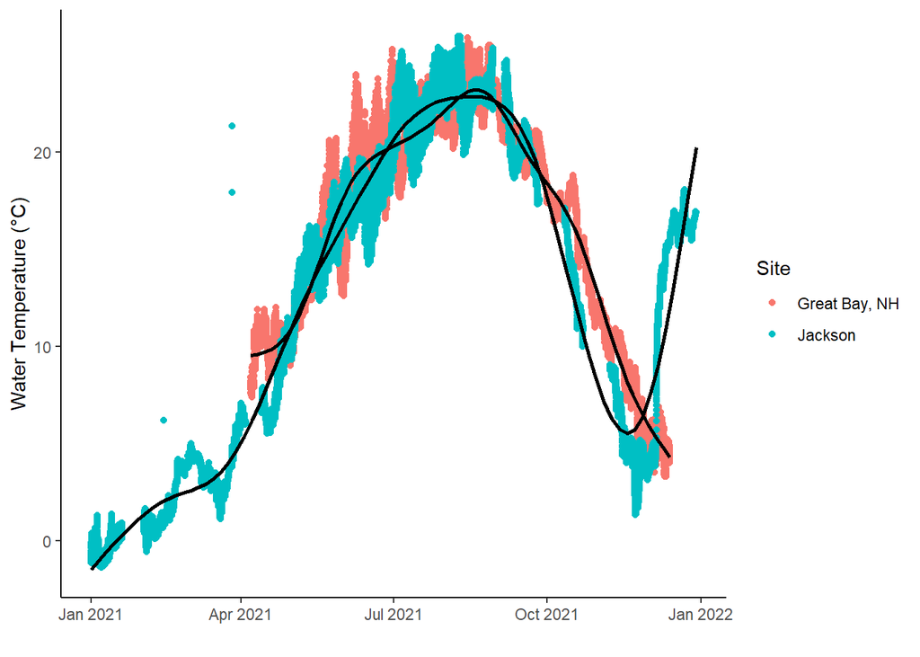

```r
ggplot(compjack, aes(x=rdate,y=WTMP,color=site))+geom_point()+theme_classic()+geom_smooth(aes(group=site),color="black")+labs(color="Site", x="",y="Water Temperature (°C)")
```

#### Recommendations for Great Bay

The temperature record from NERRS in Great Bay is likely a good candidate for use due to its proximity to our collection site. However, using data loggers in the vicinity of collection may be a good idea for accurate, site-specific temperature records.

### North Carolina

Fortunately, we collected Urosalpinx at the Duke marine lab, right next to the NDBC site BFTN7. This data source is complete and a good pairing with our collection site.

### Georgia

In the vicinity of the GA Urosalpinx collection site at the Skidaway Institute are very few environmental data sources. SKIO had previously collected temperature data from Groves Creek, right by the institute pier, but this was only for the years 2013-2015 via (https://www.bco-dmo.org/dataset/682937). We therefore opted to use more complete data from other sources, either from NDBC or NERRS.

The nearest NDBCS buoy in the Savannah river was previously shown to be too influenced by the river to be useful, so I refocused on the Sapelo NERRS site, which like Great Bay has several potential sites. However, since Sapelo is around 60-70 km from the original Urosalpinx collection site at Skidaway, I wanted to make sure there was high correlation between the 1-2 years of existing Skidaway data and the Sapelo sites.

Below, I plot the Sapelo data with Skidaway data (gcsk2) and run model comparisons between the two.

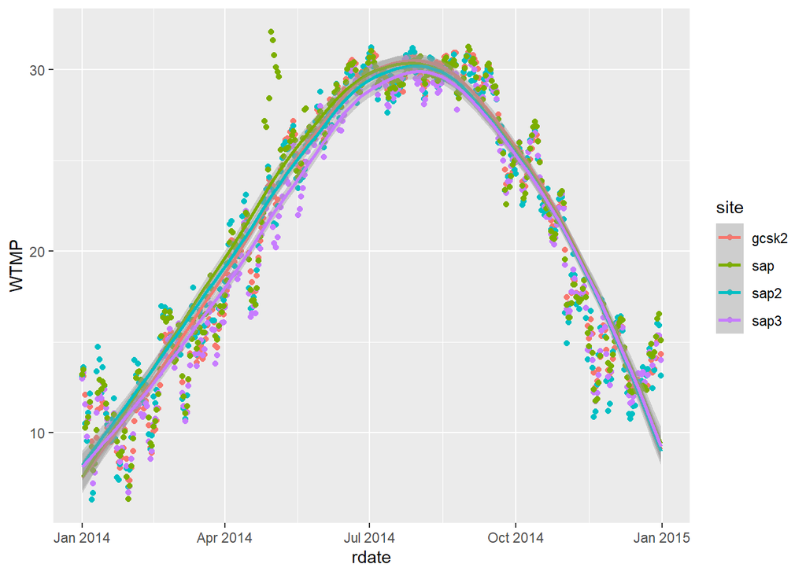

```
##
## Call:
## lm(formula = gcsk2 ~ sap, data = multi_full)
##
## Residuals:
##     Min      1Q  Median      3Q     Max
## -8.0207 -0.2345  0.2728  0.5815  2.0074
##
## Coefficients:
##              Estimate Std. Error t value Pr(>|t|)
## (Intercept) -0.170603   0.196918  -0.866    0.387
## sap          0.996431   0.008698 114.558   <2e-16 ***
## ---
## Signif. codes:  0 '***' 0.001 '**' 0.01 '*' 0.05 '.' 0.1 ' ' 1
##
## Residual standard error: 1.204 on 358 degrees of freedom
##   (5 observations deleted due to missingness)
## Multiple R-squared:  0.9734, Adjusted R-squared:  0.9734
## F-statistic: 1.312e+04 on 1 and 358 DF,  p-value: < 2.2e-16
```

```
##
## Call:
## lm(formula = gcsk2 ~ sap2, data = multi_full)
##
## Residuals:
##     Min      1Q  Median      3Q     Max
## -3.4608 -0.6012 -0.0245  0.5638  3.5656
##
## Coefficients:
##              Estimate Std. Error t value Pr(>|t|)
## (Intercept) -0.500633   0.169066  -2.961  0.00327 **
## sap2         1.023168   0.007558 135.376  < 2e-16 ***
## ---
## Signif. codes:  0 '***' 0.001 '**' 0.01 '*' 0.05 '.' 0.1 ' ' 1
##
## Residual standard error: 1.024 on 360 degrees of freedom
##   (3 observations deleted due to missingness)
## Multiple R-squared:  0.9807, Adjusted R-squared:  0.9807
## F-statistic: 1.833e+04 on 1 and 360 DF,  p-value: < 2.2e-16
```

```
##
## Call:
## lm(formula = gcsk2 ~ sap3, data = multi_full)
##
## Residuals:
##      Min       1Q   Median       3Q      Max
## -1.75382 -0.50867 -0.08683  0.41635  2.24803
##
## Coefficients:
##              Estimate Std. Error t value Pr(>|t|)
## (Intercept) -0.251481   0.118009  -2.131   0.0338 *
## sap3         1.033151   0.005458 189.283   <2e-16 ***
## ---
## Signif. codes:  0 '***' 0.001 '**' 0.01 '*' 0.05 '.' 0.1 ' ' 1
##
## Residual standard error: 0.7165 on 343 degrees of freedom
##   (20 observations deleted due to missingness)
## Multiple R-squared:  0.9905, Adjusted R-squared:  0.9905
## F-statistic: 3.583e+04 on 1 and 343 DF,  p-value: < 2.2e-16
```

You will notice that all sapelo sites had intercepts close to zero and slopes close to 1. We elected to use sap2 (SAPDCWQ) in the ProcB paper after examining these model fits and the mean/max temperatures at each site.

#### Recommendations for Georgia

It is clear that there is no ideal temperature source for our Skidaway Urosalpinx collection site. The existing Skidaway data at Groves Creek is only for 1-2 years 2013-2015, and the more complete and recent NERRS data sets from Sapelo are 60-70 km away, despite having good correlations with Skidaway data at Groves Creek.

I therefore recommend that we reach out to SKIO to ensure that we are not missing out on any data sources, and if no temperature data is readily available that we 1) collect at Skidaway and accept the Sapelo temperature series, 2) collect Urosalpinx at Sapelo instead and use Sapelo time series, or 3) deploy temperature loggers at Skidaway, which will serve as our primary temperature source.